# WFH Trends at PAWS

Karla Fettich

28 May, 2020

## Dataset description

The dataset consists of 192 entries each describing a shift between 2020-04-01 and 2020-05-26. The following variables are used in the dataset to describe a shift:

- **Timestamp**: the timestamp when the record was created via google sheets,
- **Name**: the name of the person working the shift
- **ShiftName**: the name of the shift
- **Date**: the date when the shift was worked
- **TimeStart**: time when person started working
- **TimeEnd**: time when person stopped working
- **VMLogged**: number of voicemails logged during shift
- **VMCallback**: number of voicemails called back during shift
- **EmailsReplied**: number of emails replied to during shift
- **FavMoment**: favorite moment of the shift
- **Email**: Email address of person

There are 9 people who have records of shifts:

| Name | Shifts |
| --- | --- |
| Meredyth Forbes | 50 |
| Steve Ciepiela | 50 |
| Lauren Campagnini | 29 |
| Ashley Matters | 23 |
| Angela Peterdi | 15 |
| Juliana Coculo | 11 |
| Sara Davidson | 11 |
| Rich Wilkinson | 2 |
| Ame Wiltzius | 1 |

There are 6 shifts:

| ShiftName | Shifts |
| --- | --- |
| WFH: foster@ & x.16 | 71 |
| WFH: adoptions@ & x.30/70 | 51 |
| WFH: nefoster@ & x.69 | 33 |
| WFH: foster@ and voicemails (ext. 16) | 15 |
| WFH: adoptions@ and voicemails (ext. 30 & 70) | 11 |
| WFH: applications (see 7-point list for priority) | 11 |

The following dates did not have any record of activity: 2020-04-12, 2020-05-25

## Trends in WFH volume

We will define volume as VMLogged, VMCallback and EmailsReplied, as well as a new variable called HoursWorked, which is a calculation of the time elapsed between TimeStart and TimeEnd. There were multiple entries where TimeEnd was before TimeStart:

|  | Timestamp | Name | Date | TimeStart | TimeEnd |
| --- | --- | --- | --- | --- | --- |
| 13 | 4/3/2020 16:19:50 | Sara Davidson | 2020-04-03 | 9:15:00 AM | 4:17:00 AM |
| 57 | 4/14/2020 19:03:16 | Angela Peterdi | 2020-04-14 | 2:04:00 PM | 6:09:00 AM |
| 120 | 4/30/2020 18:07:17 | Lauren Campagnini | 2020-04-30 | 9:00:00 PM | 5:00:00 PM |
| 128 | 5/2/2020 15:05:36 | Meredyth Forbes | 2020-05-02 | 11:15:00 PM | 3:00:00 PM |
| 141 | 5/6/2020 19:17:31 | Ashley Matters | 2020-05-06 | 11:00:00 AM | 7:16:00 AM |
| 186 | 5/23/2020 15:09:12 | Meredyth Forbes | 2020-05-23 | 11:00:00 AM | 3:07:00 AM |

## Daily Trends

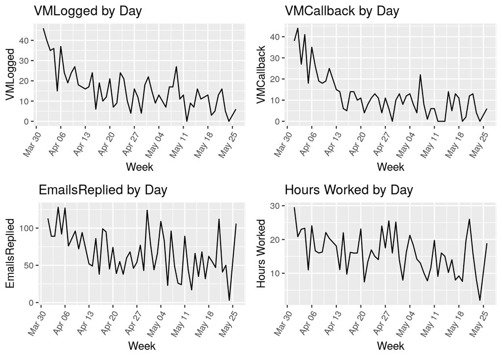

| weekLabels | Mean_VMLogged | Mean_VMCallback | Mean_EmailsReplied | Mean_HoursWorked |
| --- | --- | --- | --- | --- |
| 2020-03-30 | 34.40 | 33.60 | 102.20 | 21.54 |
| 2020-04-06 | 24.83 | 23.67 | 91.83 | 19.23 |
| 2020-04-13 | 14.86 | 11.14 | 66.29 | 15.58 |
| 2020-04-20 | 13.71 | 8.86 | 54.29 | 16.28 |
| 2020-04-27 | 13.71 | 8.57 | 69.43 | 17.48 |
| 2020-05-04 | 14.57 | 8.86 | 58.57 | 13.75 |
| 2020-05-11 | 9.71 | 5.43 | 50.14 | 13.15 |
| 2020-05-18 | 7.86 | 6.00 | 52.86 | 12.64 |
| 2020-05-25 | 6.00 | 6.00 | 106.00 | 18.88 |

The daily averages of voice mails logged, called back, emails replied and hours worked, for each week, have decreased substantially from the first week of April to the week of 5/18: a 77% decrease in VMs logged, an 82% decrease in VMs called back, a 48% decrease in emails replied. Interestingly, despite this decrease in volume, the hours worked only decreased by 41%.

Next I want to determine which type of work contributes significantly to the total workload, specifically does an increase in voice mail logging, voice mail callbacks or email replies significantly contribute to an increase in time worked. For this analysis, I convert hours worked to minutes worked, so that I can more easily interpret the contribution of each type of work. A simple linear regression is not appropriate here, since we know there are time effects and the entries are not independent of each other. I therefore fit a linear model with time series components.

```
##
## Call:
## tslm(formula = MinsWorked ~ VMLogged + VMCallback + EmailsReplied,
##     data = dailyTS)
##
## Residuals:
##    Min     1Q Median     3Q    Max
## -433.4 -191.7  -32.0  172.0  762.8
##
## Coefficients:
##               Estimate Std. Error t value Pr(>|t|)
## (Intercept)    277.475     84.260   3.293  0.00179 **
## VMLogged        15.499      6.416   2.415  0.01926 *
## VMCallback     -10.149      6.814  -1.490  0.14237
## EmailsReplied    8.224      1.421   5.787 4.17e-07 ***
## ---
## Signif. codes:  0 '***' 0.001 '**' 0.01 '*' 0.05 '.' 0.1 ' ' 1
##
## Residual standard error: 257.4 on 52 degrees of freedom
## Multiple R-squared:  0.5882, Adjusted R-squared:  0.5644
## F-statistic: 24.76 on 3 and 52 DF,  p-value: 4.346e-10
```

The model tells us that 56% of the time worked data can be explained by number of VMs logged, number of VMs called back and number of emails replied to (the remaining components that contribute to time worked are not known - they could potentially be a result of individual work styles). Among the 3 types of work examined, we can see that Replying to Emails contributes most strongly to the total time worked, with each email response adding an estimated 8 minutes to the total time worked. Logging VMs is also a significant factor, with each VM logged adding an estimated 16 minutes to the total work time. Calling back VMs does not appear to significantly impact time worked.

Next I will use the data to predict estimated future workload.

I will test several time series forecast models and pick the one with the lowest MAD (Mean Absolute Deviation) score, which is essentially a numeric representation of how far from truth, on average, the predictions deviate (the lower the score, the closer to truth). I will expect the model to give me a forecast for the following 2 weeks, and I will evaluate the MAD score by first dividing the whole time series into 2: a training set (all data from start to 2 weeks prior to the end of data), and a test set, which will include the last 2 weeks in the dataset. I will use the training data to create the model, and make predictions for the test data, which I can then compare to the true observed value.

| model | MAD | avg_forecast | avg_lo80 | avg_hi80 | avg_lo95 | avg_hi95 |
| --- | --- | --- | --- | --- | --- | --- |
| Simple Exponential Smoothing | 5.83 | 14.64 | 6.532918 | 22.74860 | 2.2408861 | 27.04063 |
| Naive Forecast | 5.92 | 9.07 | -18.685167 | 36.82517 | -33.3778644 | 51.51786 |
| Holt’s Trend Method | 5.64 | 12.24 | 4.627362 | 19.85729 | 0.5962436 | 23.88841 |
| ARIMA | 6.45 | 16.51 | 8.817008 | 24.20775 | 4.7433229 | 28.28144 |
| TBATS | 6.51 | 16.40 | 9.446131 | 23.35171 | 5.7655479 | 27.03229 |

Given that the Holt’s Trend Method has the smallest MAD score, I’ll choose that one to make forecasts for the next 2 weeks post the last date of the dataset.

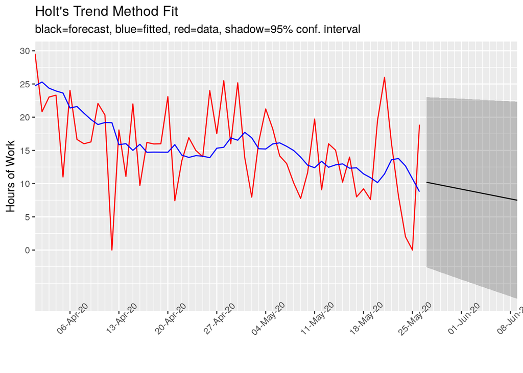

|  | date | forecast | lo80 | hi80 | lo95 | hi95 |
| --- | --- | --- | --- | --- | --- | --- |
| 57 | 2020-05-27 | 10.21 | 1.84 | 18.58 | -2.59 | 23.01 |
| 58 | 2020-05-28 | 10.00 | 1.52 | 18.48 | -2.97 | 22.97 |
| 59 | 2020-05-29 | 9.79 | 1.21 | 18.38 | -3.34 | 22.92 |
| 60 | 2020-05-30 | 9.58 | 0.89 | 18.28 | -3.71 | 22.88 |
| 61 | 2020-05-31 | 9.38 | 0.58 | 18.17 | -4.08 | 22.83 |
| 62 | 2020-06-01 | 9.17 | 0.27 | 18.07 | -4.45 | 22.78 |
| 63 | 2020-06-02 | 8.96 | -0.05 | 17.96 | -4.81 | 22.73 |
| 64 | 2020-06-03 | 8.75 | -0.36 | 17.86 | -5.18 | 22.68 |
| 65 | 2020-06-04 | 8.54 | -0.67 | 17.75 | -5.54 | 22.62 |
| 66 | 2020-06-05 | 8.33 | -0.97 | 17.64 | -5.90 | 22.57 |
| 67 | 2020-06-06 | 8.12 | -1.28 | 17.53 | -6.26 | 22.51 |
| 68 | 2020-06-07 | 7.92 | -1.59 | 17.42 | -6.62 | 22.45 |
| 69 | 2020-06-08 | 7.71 | -1.89 | 17.31 | -6.98 | 22.39 |
| 70 | 2020-06-09 | 7.50 | -2.20 | 17.20 | -7.33 | 22.33 |

The model forecasts a decreasing trend, estimating that on average across the next 14 days, the daily hours worked will be ~9 hours, starting at 10 hours on average on May 27 and 28, and decreasing to 7.50 hours by June 9th. This model estimates that there is an 80% chance that the true hours worked per day in the following 2 weeks will not exceed 18.5 hours/day, and there is a 95% chance that the true hours worked per day in the following 2 weeks will not exceed 23 hours. Given that the confidence interval is fairly wide, it may be adviseable to plan for the forecasted number of hours per day, while having a number of volunteers on stand-by in case daily variation exceeds the expected workload.

## Days of the Week

### Volume by type of WFH? does that follow trends?

### Most efficient staff members at WFH? (although difficulty of task is not pictured here)